# Graphic and Table Examples

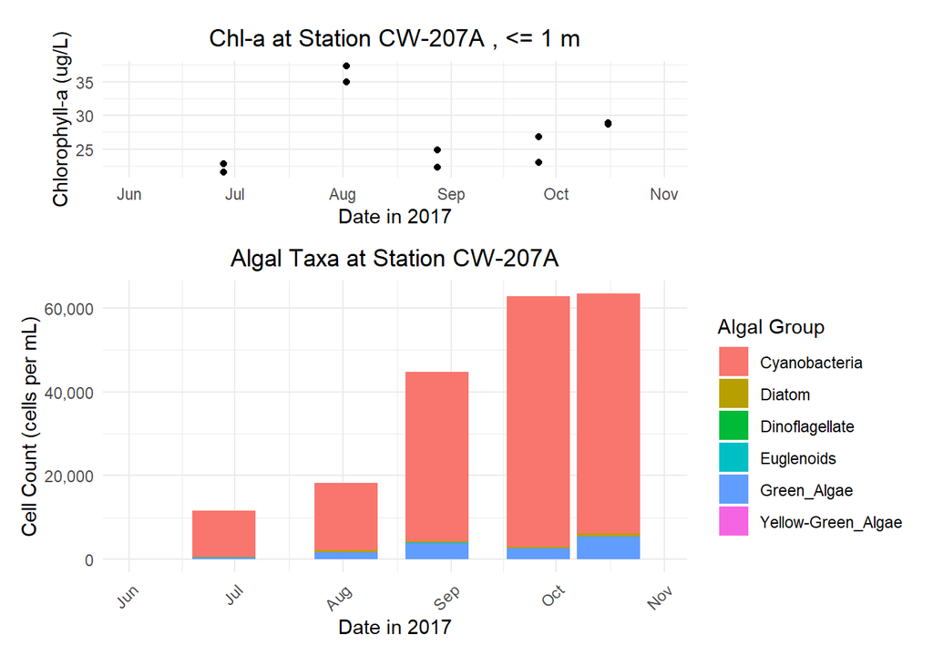

Figure X: CW-207A (Lake Wateree) Chlorophyll-a and Algae Count

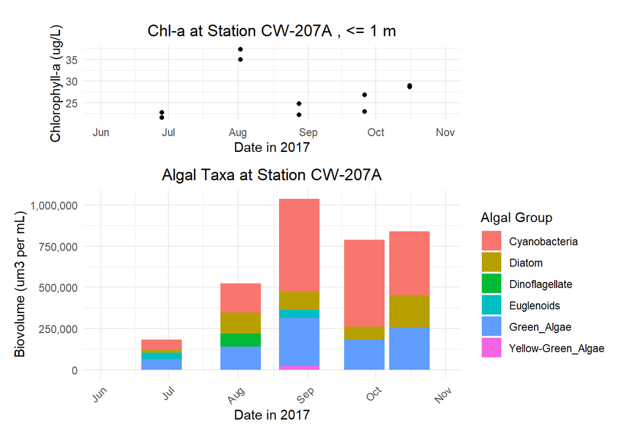

Figure X: CW-207A (Lake Wateree) Chlorophyll-a and Algae Biovolume

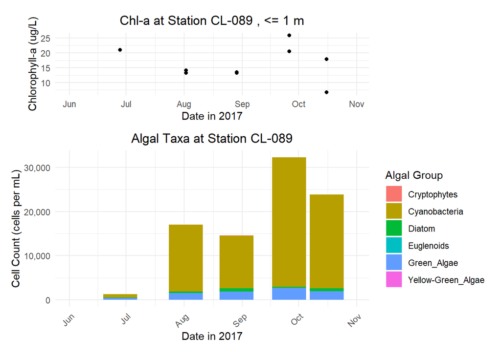

Figure X: CL-089 (Lake Wateree) Chlorophyll-a and Algae Count

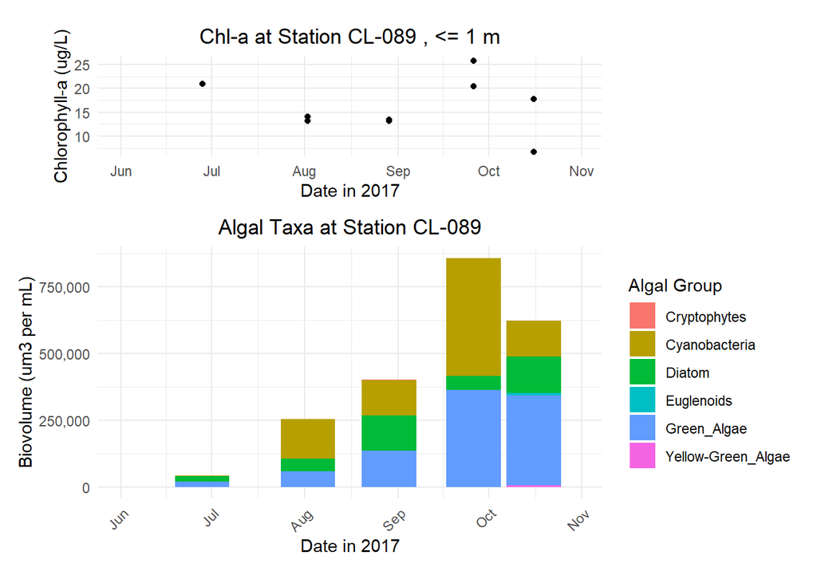

Figure X: CL-089 (Lake Wateree) Chlorophyll-a and Algae Biovolume

## Cyanobacteria Counts and WHO Risk Thresholds

These charts compare the 2017 cyanobacteria counts to WHO risk thresholds

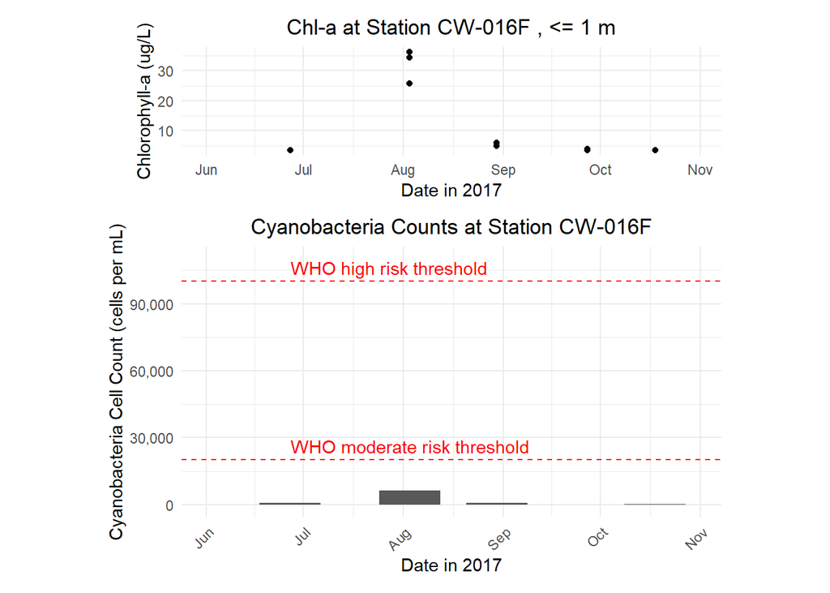

Figure X: Cyanobacteria counts at station CW-16F (Fishing Creek Reservoir).

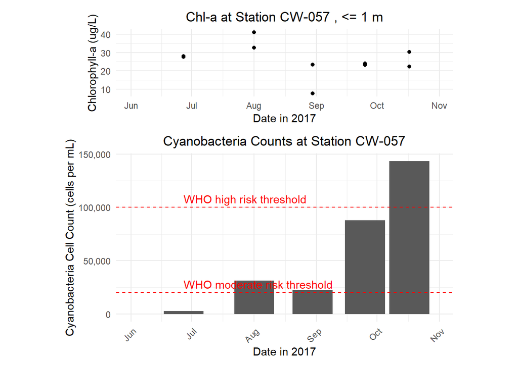

Figure X: Cyanobacteria counts at station CW-057 (Fishing Creek Reservoir).

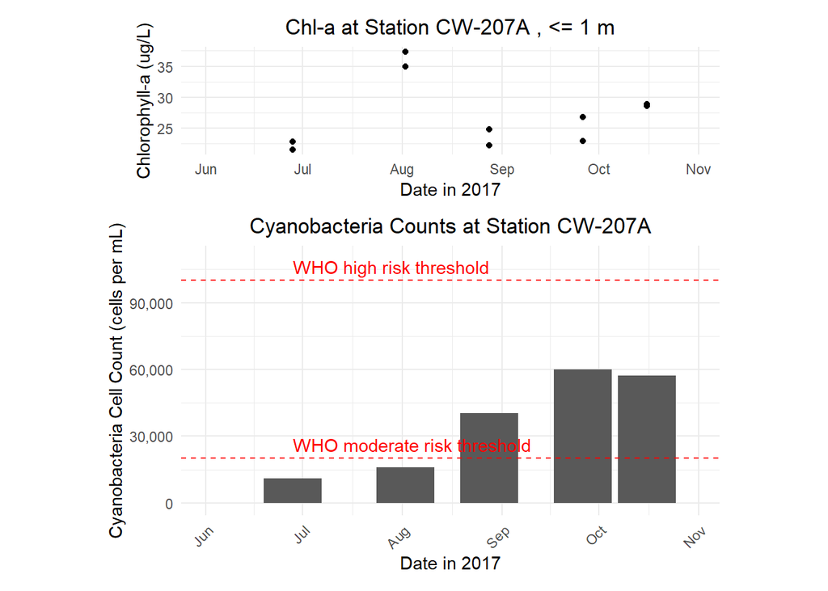

Figure X: Cyanobacteria counts at station CW-207A (Lake Wateree).

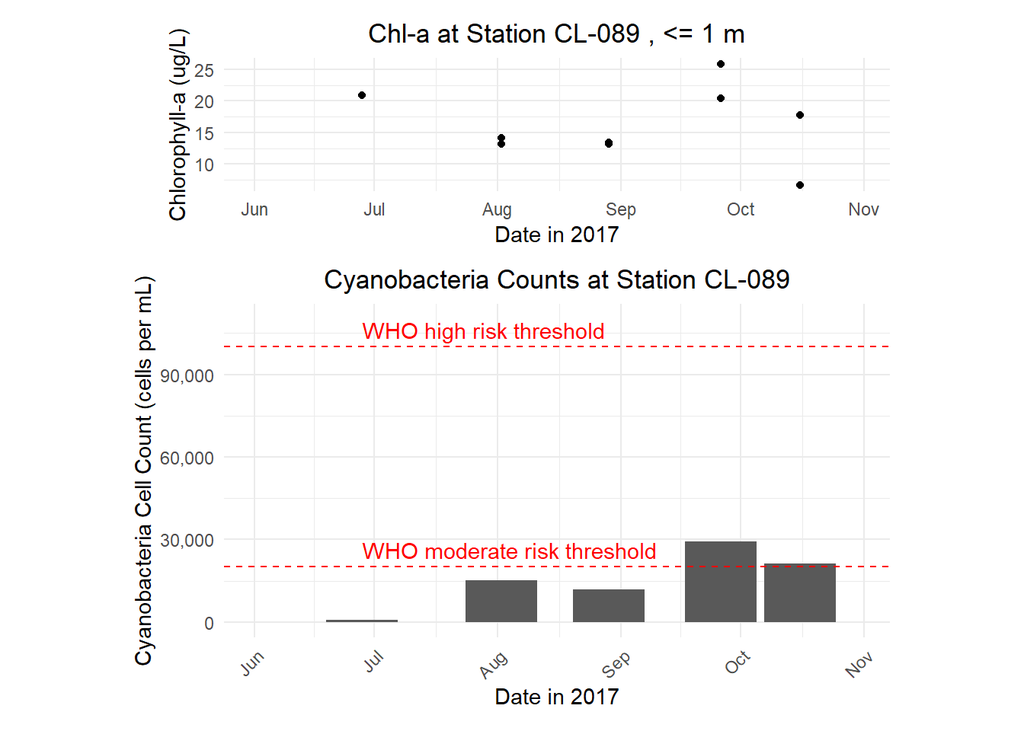

Figure X: Cyanobacteria counts at station CL-089 (Lake Wateree).

## Scatterplot of Cyanobacteria Counts vs. Chlorophyll-a

These plots are intended to explore the relation between cyanobacteria cell counts and chlorophyll-a.

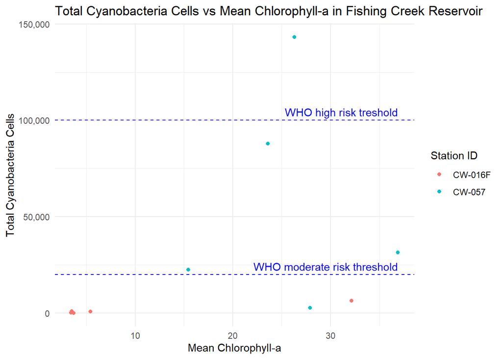

Figure X: Cyanobacteria count vs. chla, Fishing Creek Reservoir

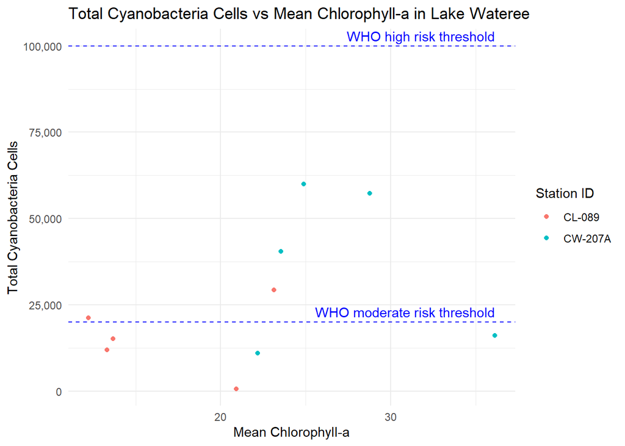

Figure X: Cyanobacteria count vs. chla, Lake Wateree

# Percent Cynaobacteria Biovolume vs Chlorophyll-a

These plots are intended to explore the relation between percent cyanobacteria biovolume and chlorophyll-a.

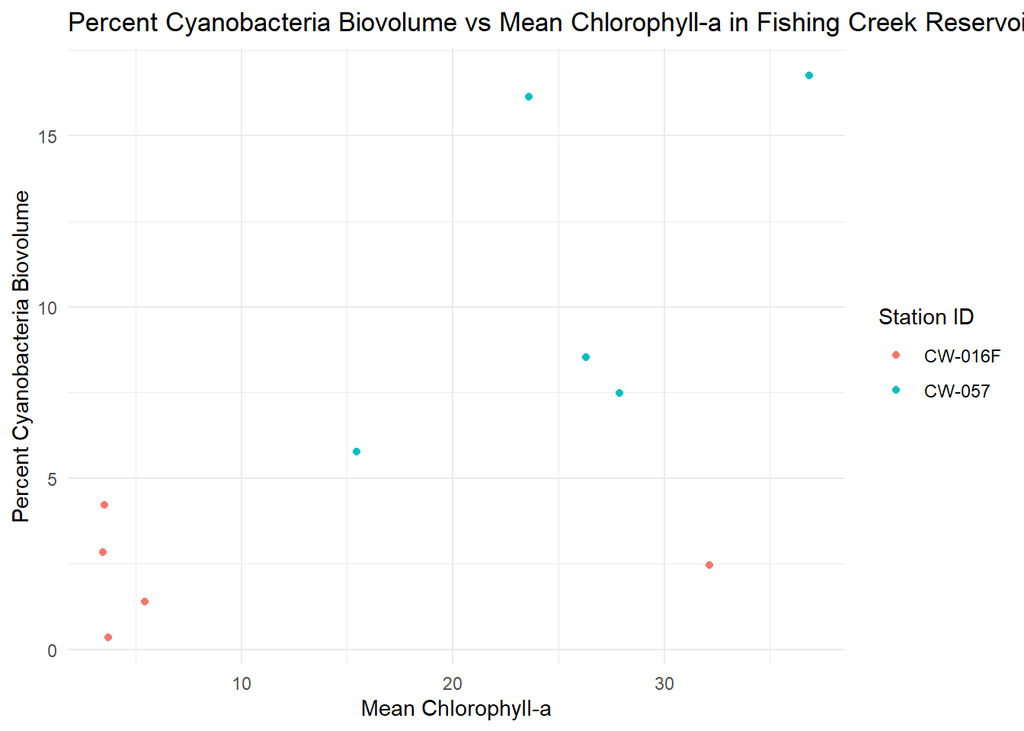

Figure X: Cyanobacteria biovolume vs. chla, Fishing Creek Reservoir

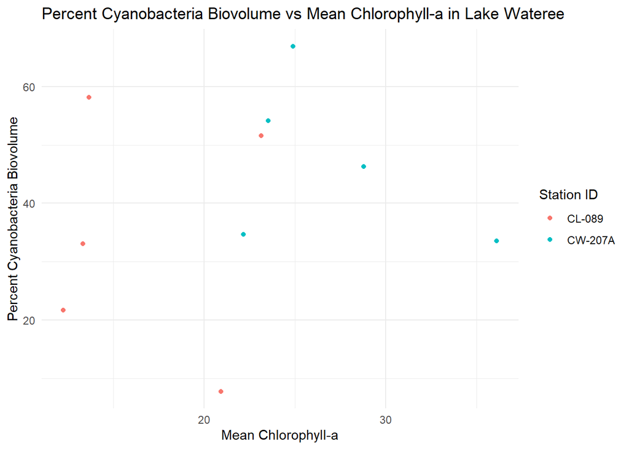

Figure X: Cyanobacteria biovolume vs. chla, Lake Wateree